# Leave-One-Out Brier Score for Bayesian Survival Models

# Brier Score (LOO-PSIS)

Now, suppose $\{\theta_s\}_{s=1\dots S}$ is a (correlated) sequence of latent model parameters drawn from the posterior, given *all* observed times (including the one from individual $i$). We then can approximate $S_i(t\vert \mathbf{T}_{-i})$ as follows

$$S_i(t\vert \mathbf{T}_{-i}) \approx \frac{\sum_{s=1}^S r_{s,i} S_i(t\vert \theta_s)}{\sum_{s=1}^S r_{s,i}}$$

where $S_i(t\vert \theta_s)$ is the probability that individual $i$ survives beyond time $t$, given latent parameters $\theta_s$ and

$$r_{s,i} \equiv \frac{1}{p(T_i\vert \theta_s)}$$
Now, define

$$\eta_{i,t} \equiv \left\{ 1_{\{T_i > t\}} - S_i(t\vert \mathbf{T}_{-i})\right\}^2$$

Based on the residuals $\eta_{i}(t)$ we define, following Gerds et al, the inverse probability of censoring weighted estimator $\Omega(t)$, defined as

$$\Omega(t)\equiv \frac{1}{N} \sum_{i=1}^N w_i(t)\eta_{i}(t)^2$$

with

$$w_i(t) \equiv \frac{\mathbf{1}_{\{T_i \leq t\}} \delta_i}{G_i(T_i)} + \frac{\mathbf{1}_{\{T_i > t\}}}{G_i(t)}$$

Here $\delta_i$ is the event indicator, i.e. $\delta_i = 1$ iff individual experienced the event and $0$ otherwise. Moreover $G_i(t)$ is the probability that the censoring time $C_i$ is exceeds $t$ for patient $i$. Note that for both the event and censoring survival functions we indicate a potential dependence on covariates by adding the index $i$. $G_i(t)$ can be obtained by fitting, for example, a Cox model to the data with reversed censoring indicators. By introducing a weighting based on $G_i$ we guarantee that the estimator’s bias $\Omega(t)$ does not depent on the survival model (otherwise model comparison would be hard), see Gerds et al. It can be shown, see Gerds et al., that under weaks conditions, $\Omega(t)$ is a uniformly consistent estimator for the expected mean squared error in time (aka Brier score).

```r
intercepts <- as.vector(post[,,"intercept"])
betas <- t(matrix(post[,,sprintf("betas[%d]" ,1:ncol(X))], dim(post)[1]*dim(post)[2], ncol(X)))
X_surv = as.matrix(c(0,1))
times_pec <- seq(0, time_max, length.out = 100)
survs1 <- purrr::map(times_pec, ~rowMeans(surv_const_t(., X, intercepts, betas)))
survs1 <- do.call(cbind, survs1)

log_ratios <- -post[,,sprintf("log_lik[%d]",1:N)]
r_eff <- relative_eff(exp(log_ratios))
psis_result <- psis(log_ratios, r_eff = r_eff)
w <- matrix(weights(psis_result, log=FALSE), nrow=dim(X)[1], byrow = T) # TODO: check if this is correct reshaping!
survs_loo1 <- do.call(cbind, purrr::map(times_pec,~surv_loo(surv_const_t(., X, intercepts, betas), w)))
```

```r
intercepts <- as.vector(post2[,,"intercept"])
betas <- t(matrix(post2[,,sprintf("betas[%d]" ,1:ncol(X))], dim(post2)[1]*dim(post2)[2], ncol(X)))
gammas <- t(matrix(post2[,,sprintf("gammas[%d]", 1:nbasis)], dim(post2)[1]*dim(post2)[2], nbasis))
times_pec <- seq(0, time_max, length.out = 100)
i_spline_basis_evals <- iSpline(times_pec, knots=knots, degree=mspline_degree,
                                intercept=FALSE, Boundary.knots = c(0, time_max))

survs2 <- purrr::map(1:length(times_pec), ~rowMeans(surv_mspline_t(i_spline_basis_evals[.,], X, gammas,intercepts, betas)))
survs2 <- do.call(cbind, survs2)

log_ratios2 <- -post2[,,sprintf("log_lik[%d]",1:N)]
r_eff2 <- relative_eff(exp(log_ratios2))
psis_result2 <- psis(log_ratios2, r_eff = r_eff2)
w2<- matrix(weights(psis_result2, log=FALSE), nrow=dim(X)[1], byrow = T) # TODO: check if this is correct reshaping!


survs_loo2 <- do.call(cbind, purrr::map(1:length(times_pec),~surv_loo(surv_mspline_t(i_spline_basis_evals[.,], X, gammas, intercepts, betas), w2)))
```

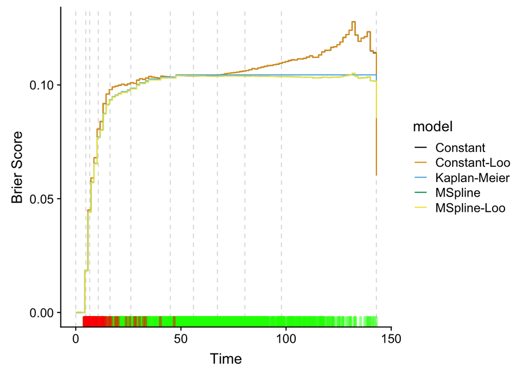

```r
pec_rslt <- pec(list("MSpline-Loo"=survs_loo2,
                     "Constant-Loo"=survs_loo1,
                     "MSpline"=survs2,
                     "Constant"=survs1
                     ), formula =Surv(time,d)~race+sex , data=df, exact = F, times = times_pec,cens.model="marginal",
                splitMethod="none",
                B=0,
                verbose=TRUE)

df_pec <- tibble(time=pec_rslt$time, bs=pec_rslt$AppErr[["Constant-Loo"]], model="Constant-Loo") %>%
  bind_rows(tibble(time=pec_rslt$time, bs=pec_rslt$AppErr[["MSpline-Loo"]], model="MSpline-Loo")) %>%
  bind_rows(tibble(time=pec_rslt$time, bs=pec_rslt$AppErr[["Constant"]], model="Constant")) %>%
  bind_rows(tibble(time=pec_rslt$time, bs=pec_rslt$AppErr[["MSpline"]], model="MSpline")) %>%
  bind_rows(tibble(time=pec_rslt$time, bs=pec_rslt$AppErr[["Reference"]], model="Kaplan-Meier"))
ggplot(data=df_pec) +
  geom_vline(xintercept = c(0,knots, time_max), alpha=.5, color='gray', linetype='dashed')+
  geom_step(aes(x=time, y=bs, color=model))+
  geom_rug(data=tibble(times=times[is_censored]), aes(x=times), col="green",alpha=0.5, size=1.25)+
  geom_rug(data=tibble(times=times[!is_censored]), aes(x=times), col="red",alpha=0.5, size=1.25)+
  ylab("Brier Score")+
  xlab("Time")+
  scale_fill_manual(values=cbbPalette)+
  scale_colour_manual(values=cbbPalette)
```

```r
trsf_bs <- function(m) {
    dplyr::filter(df_pec, model==m) %>%
    dplyr::select(time, bs) %>%
    dplyr::rename(!!paste("bs",m,sep="_") := bs)
}

purrr::map(unique(df_pec$model),trsf_bs) %>%
  purrr::reduce(left_join, by = "time")
```

| time | bs_Constant-Loo | bs_MSpline-Loo | bs_Constant | bs_MSpline | bs_Kaplan-Meier |
| --- | --- | --- | --- | --- | --- |
| 0.000000 | 7.045392e-30 | 6.893053e-30 | 0.000000e+00 | 0.000000e+00 | 0.00000000 |
| 1.443919 | 1.202895e-05 | 2.164024e-06 | 1.203118e-05 | 2.163983e-06 | 0.00000000 |
| 2.887837 | 4.793460e-05 | 7.350594e-05 | 4.794347e-05 | 7.351491e-05 | 0.00000000 |
| 4.331756 | 1.843529e-02 | 1.837933e-02 | 1.843529e-02 | 1.837939e-02 | 0.01835776 |
| 5.775675 | 4.506971e-02 | 4.401896e-02 | 4.506973e-02 | 4.401827e-02 | 0.04405426 |
| 7.219593 | 5.913247e-02 | 5.712026e-02 | 5.913227e-02 | 5.711961e-02 | 0.05728225 |
| 8.663512 | 6.798878e-02 | 6.537139e-02 | 6.798863e-02 | 6.537111e-02 | 0.06554945 |
| 10.107430 | 8.062371e-02 | 7.688577e-02 | 8.062182e-02 | 7.687981e-02 | 0.07705258 |
| 11.551349 | 8.392694e-02 | 8.013099e-02 | 8.392500e-02 | 8.012496e-02 | 0.08027221 |
| 12.995268 | 9.181295e-02 | 8.730608e-02 | 9.180861e-02 | 8.729338e-02 | 0.08748457 |

[output cut: 90 more lines]

### Constant only

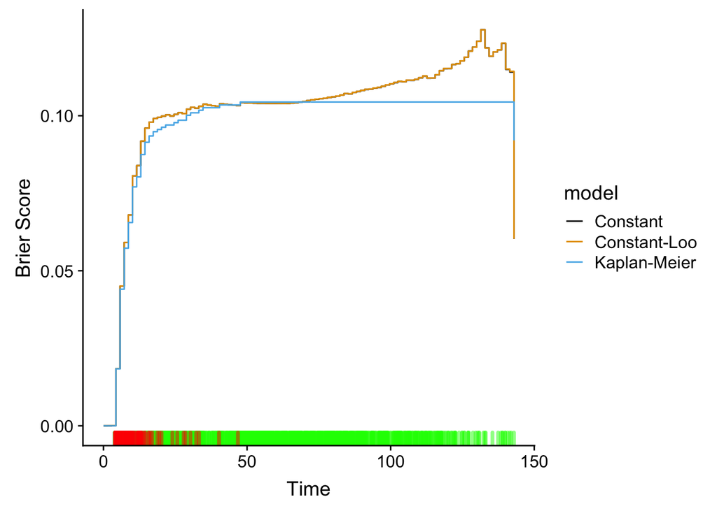

```r
pec_rslt <- pec(list("Constant-Loo"=survs_loo1,
                     "Constant"=survs1
                     ), formula =Surv(time,d)~race+sex , data=df, exact = F, times = times_pec,cens.model="marginal",
                splitMethod="none",
                B=0,
                verbose=TRUE)

df_pec <- tibble(time=pec_rslt$time, bs=pec_rslt$AppErr[["Constant-Loo"]], model="Constant-Loo") %>%
  bind_rows(tibble(time=pec_rslt$time, bs=pec_rslt$AppErr[["Constant"]], model="Constant")) %>%
    bind_rows(tibble(time=pec_rslt$time, bs=pec_rslt$AppErr[["Reference"]], model="Kaplan-Meier"))


ggplot(data=df_pec) +
  geom_step(aes(x=time, y=bs, color=model))+
  geom_rug(data=tibble(times=times[is_censored]), aes(x=times), col="green",alpha=0.5, size=1.25)+
  geom_rug(data=tibble(times=times[!is_censored]), aes(x=times), col="red",alpha=0.5, size=1.25)+
  ylab("Brier Score")+
  xlab("Time")+
  scale_fill_manual(values=cbbPalette)+
  scale_colour_manual(values=cbbPalette)
```

```r
purrr::map(unique(df_pec$model),trsf_bs) %>%
  purrr::reduce(left_join, by = "time")
```

| time | bs_Constant-Loo | bs_Constant | bs_Kaplan-Meier |
| --- | --- | --- | --- |
| 0.000000 | 7.045392e-30 | 0.000000e+00 | 0.00000000 |
| 1.443919 | 1.202895e-05 | 1.203118e-05 | 0.00000000 |
| 2.887837 | 4.793460e-05 | 4.794347e-05 | 0.00000000 |
| 4.331756 | 1.843529e-02 | 1.843529e-02 | 0.01835776 |
| 5.775675 | 4.506971e-02 | 4.506973e-02 | 0.04405426 |
| 7.219593 | 5.913247e-02 | 5.913227e-02 | 0.05728225 |
| 8.663512 | 6.798878e-02 | 6.798863e-02 | 0.06554945 |
| 10.107430 | 8.062371e-02 | 8.062182e-02 | 0.07705258 |
| 11.551349 | 8.392694e-02 | 8.392500e-02 | 0.08027221 |
| 12.995268 | 9.181295e-02 | 9.180861e-02 | 0.08748457 |

[output cut: 90 more lines]

### MSpline only

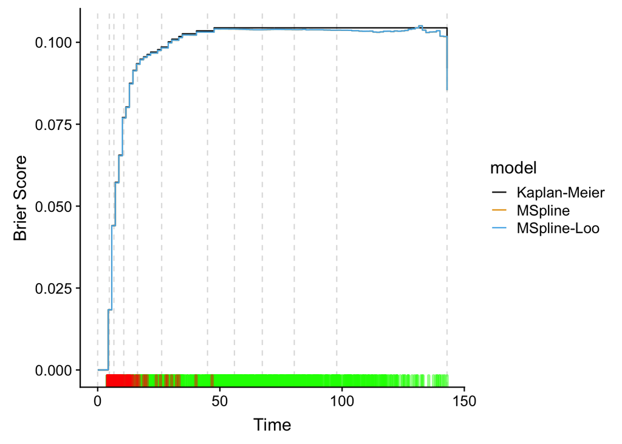

```r
pec_rslt <- pec(list("MSpline-Loo"=survs_loo2,
                     "MSpline"=survs2
                     ), formula =Surv(time,d)~race+sex , data=df, exact = F, times = times_pec,cens.model="marginal",
                splitMethod="none",
                B=0,
                verbose=TRUE)

df_pec <- tibble(time=pec_rslt$time, bs=pec_rslt$AppErr[["MSpline-Loo"]], model="MSpline-Loo") %>%
  bind_rows(tibble(time=pec_rslt$time, bs=pec_rslt$AppErr[["MSpline"]], model="MSpline")) %>%
  bind_rows(tibble(time=pec_rslt$time, bs=pec_rslt$AppErr[["Reference"]], model="Kaplan-Meier"))


ggplot(data=df_pec) +
  geom_vline(xintercept = c(0,knots, time_max), alpha=.5, color='gray', linetype='dashed')+
  geom_step(aes(x=time, y=bs, color=model))+
  geom_rug(data=tibble(times=times[is_censored]), aes(x=times), col="green",alpha=0.5, size=1.25)+
  geom_rug(data=tibble(times=times[!is_censored]), aes(x=times), col="red",alpha=0.5, size=1.25)+
  ylab("Brier Score")+
  xlab("Time")+
  scale_fill_manual(values=cbbPalette)+
  scale_colour_manual(values=cbbPalette)
```

```r
purrr::map(unique(df_pec$model),trsf_bs) %>%
  purrr::reduce(left_join, by = "time")
```

| time | bs_MSpline-Loo | bs_MSpline | bs_Kaplan-Meier |
| --- | --- | --- | --- |
| 0.000000 | 6.893053e-30 | 0.000000e+00 | 0.00000000 |
| 1.443919 | 2.164024e-06 | 2.163983e-06 | 0.00000000 |
| 2.887837 | 7.350594e-05 | 7.351491e-05 | 0.00000000 |
| 4.331756 | 1.837933e-02 | 1.837939e-02 | 0.01835776 |
| 5.775675 | 4.401896e-02 | 4.401827e-02 | 0.04405426 |
| 7.219593 | 5.712026e-02 | 5.711961e-02 | 0.05728225 |
| 8.663512 | 6.537139e-02 | 6.537111e-02 | 0.06554945 |
| 10.107430 | 7.688577e-02 | 7.687981e-02 | 0.07705258 |
| 11.551349 | 8.013099e-02 | 8.012496e-02 | 0.08027221 |
| 12.995268 | 8.730608e-02 | 8.729338e-02 | 0.08748457 |

[output cut: 90 more lines]